# Coursera - Practical Machine Learning -JHU

Minh Nguyen

May 29, 2016

# Executive Summary

One thing that people regularly do is quantify how much of a particular activity they do, but they rarely quantify how well they do it. Using devices such as Jawbone Up, Nike FuelBand, and Fitbit it is now possible to collect a large amount of data about personal activity relatively inexpensively. In here we aim to predict how well people perform their exercise, using he data from the fitness equipment.

## Preparation

Remove any existing lists and load required packages

```r
rm(list=ls())
library(ggplot2)
library(lattice)
library(corrplot)
library(caret)
library(randomForest)
```

Read data from Cloudfront into R. There are 19622 records in the training set and 20 records in the test set. Both sets have 160 variables

```r
data_training=read.csv(file="https://d396qusza40orc.cloudfront.net/predmachlearn/pml-training.csv",na.strings= c("NA",""," "))
data_testing=read.csv(file="https://d396qusza40orc.cloudfront.net/predmachlearn/pml-testing.csv",na.strings= c("NA",""," "))
```

Checking the dimensions of the new data sets

1. Training set (number of row, column):

```
## [1] 19622   160
```

2. Test set (number of row, column):

```
## [1]  20 160
```

Remove columns with NAs in the training set to reduce noise for the model.

```r
data_training00 <- data_training[,colSums(is.na(data_training))==0]
data_testing00  <- data_testing[,colSums(is.na(data_testing))==0]
```

Remove unique identifiers columns 1 to 7 in the training set.

```r
data_training_prepared <- data_training00[,-c(1:7)]
data_testing_prepared <- data_testing00[,-c(1:7)]
```

Split the training data into training and cross-validation partitions with a 7:3 ratio. This allows training a model and testing it against a cross-validation set before running it on the final 20 test cases in the test.csv

```r
inTrain <- createDataPartition(y=data_training_prepared$classe,p=0.7,list=FALSE)
training<-data_training_prepared[inTrain,]
validating<-data_training_prepared[-inTrain,]
```

## Building a model

The Random Forest method is chosen because it is a highly accurate and widely used method for prediction. In addition, classification and regression trees, which the Random Forest is based on, do not have the same type of multicollinearity issues like in multiple linear regression. Splits are based on a best chosen split criteria with the Gini index being the most commonly used one. Before building a model, a correlation matrix will show how strong the correlation between the variables are to each other:

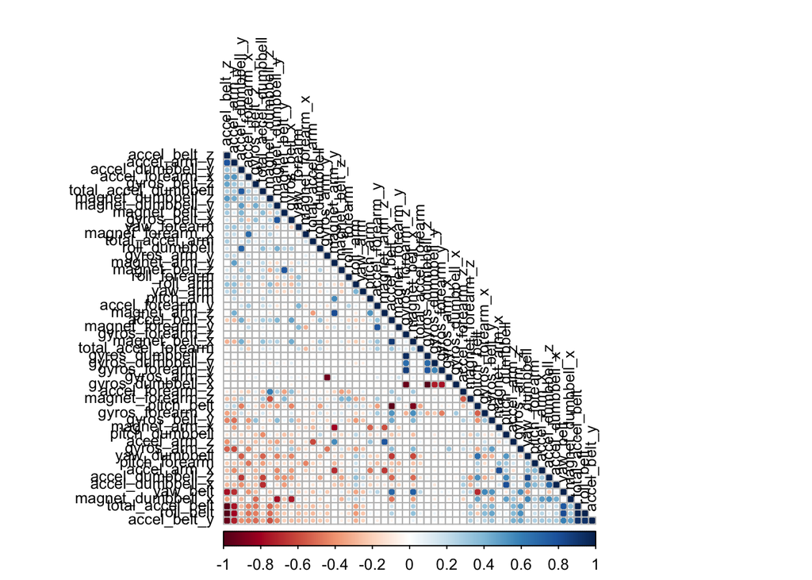

```r
correlMatrix <- cor(training[, -length(training)])
corrplot(correlMatrix, order = "FPC", method = "circle", type = "lower", tl.cex = 0.8,  tl.col = rgb(0, 0, 0))
```

A red and blue dot on the table indicates a negative and possitive correlation repectively.

These is not much concern about the collinearity on the variables in this dataset. Therefore, we proceed to train the model:

```r
modelFit<-randomForest(classe~.,  data=training)
modelFit
```

```
##
## Call:
##  randomForest(formula = classe ~ ., data = training)
##                Type of random forest: classification
##                      Number of trees: 500
## No. of variables tried at each split: 7
##
##         OOB estimate of  error rate: 0.52%
## Confusion matrix:
##      A    B    C    D    E  class.error
## A 3903    2    0    0    1 0.0007680492
## B   14 2639    5    0    0 0.0071482318
## C    0   15 2379    2    0 0.0070951586
## D    0    0   20 2229    3 0.0102131439
## E    0    0    3    6 2516 0.0035643564
```

## Cross-validation

```r
pred<-predict(modelFit,validating)
```

Determine model accuracy by using the confusion matrix

```r
confusionMatrix(validating$classe,pred)
```

```
## Confusion Matrix and Statistics
##
##           Reference
## Prediction    A    B    C    D    E
##          A 1674    0    0    0    0
##          B    7 1127    5    0    0
##          C    0    8 1017    1    0
##          D    0    0   15  948    1
##          E    0    0    0    3 1079
##
## Overall Statistics
##
##                Accuracy : 0.9932
##                  95% CI : (0.9908, 0.9951)
##     No Information Rate : 0.2856
##     P-Value [Acc > NIR] : < 2.2e-16
##
##                   Kappa : 0.9914
##  Mcnemar's Test P-Value : NA
##
## Statistics by Class:
##
##                      Class: A Class: B Class: C Class: D Class: E
## Sensitivity            0.9958   0.9930   0.9807   0.9958   0.9991
## Specificity            1.0000   0.9975   0.9981   0.9968   0.9994
## Pos Pred Value         1.0000   0.9895   0.9912   0.9834   0.9972
## Neg Pred Value         0.9983   0.9983   0.9959   0.9992   0.9998
## Prevalence             0.2856   0.1929   0.1762   0.1618   0.1835
## Detection Rate         0.2845   0.1915   0.1728   0.1611   0.1833
## Detection Prevalence   0.2845   0.1935   0.1743   0.1638   0.1839
## Balanced Accuracy      0.9979   0.9952   0.9894   0.9963   0.9992
```

## Prediction

Perform perdiction the a new data set containing 20 test cases

```r
predTest<- predict(modelFit, data_testing_prepared)
predTest
```

```
##  1  2  3  4  5  6  7  8  9 10 11 12 13 14 15 16 17 18 19 20
##  B  A  B  A  A  E  D  B  A  A  B  C  B  A  E  E  A  B  B  B
## Levels: A B C D E
```

## Conclusion

Using the Random Forest method and the data provided from fitness instruments, how well an excercise if performed can be accurately predicted with a relatively straightfoward model